# Klasyfikacja Win

Sobański Wiktor

Zestaw zadań na ocenę 4.

## Zadania

### Zadanie a)

#### Treść zadania:

Dla każdej wartości (klasy) zmiennej Z znaleźć estymator jądrowy gęstości dwuwymiarowej opisującej rozkład X i Y. Następnie za pomocą otrzymanych gęstości wyznaczyć obszary klasyfikacji (zrobić odpowiedni rysunek) i wyznaczyć procent poprawnej reklasyfikacji.

#### Rozwiązanie:

Ramka danych:

```r
x = data.frame(read.csv("wine.csv", sep = ",", header = T))
x = x[c("Wine", "Acl", "OD")]
x$Wine = as.factor(x$Wine)
x
```

| Wine | Acl | OD |
| --- | --- | --- |
| 1 | 15.6 | 3.92 |
| 1 | 11.2 | 3.40 |
| 1 | 18.6 | 3.17 |
| 1 | 16.8 | 3.45 |
| 1 | 21.0 | 2.93 |
| 1 | 15.2 | 2.85 |
| 1 | 14.6 | 3.58 |
| 1 | 17.6 | 3.58 |
| 1 | 14.0 | 2.85 |
| 1 | 16.0 | 3.55 |

[output cut: 168 more lines]

W celu znalezienia estymatora jądrowego gęstości dwuwymiarowej wykorzystana zostanie funkcja *kde2d* z pakietu *MASS*.

```r
gest1 = kde2d(x$Acl[x$Wine == "1"], x$OD[x$Wine == "1"], n = 50, lims = c(10, 30, 1, 5))
gest2 = kde2d(x$Acl[x$Wine == "2"], x$OD[x$Wine == "2"], n = 50, lims = c(10, 30, 1, 5))
gest3 = kde2d(x$Acl[x$Wine == "3"], x$OD[x$Wine == "3"], n = 50, lims = c(10, 30, 1, 5))
```

Znalezione estymatory jądrowe można zaprezentować graficznie na jednym wykresie razem z punktami dla poszczególnych Win:

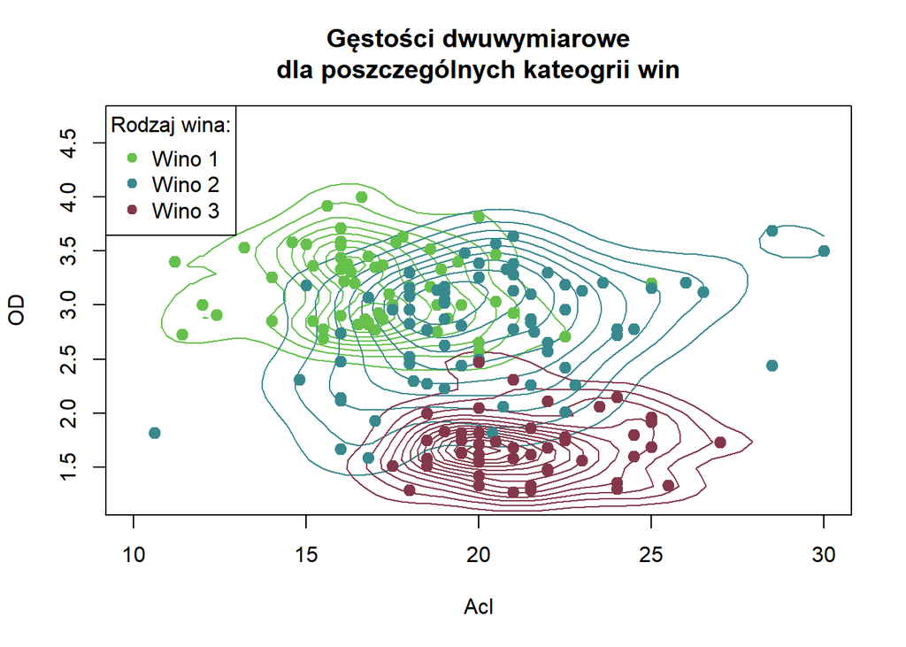

```r
contour(gest1,lwd=1,method="simple", col = "#65C14C",
        xlab = "Acl",
        ylab = 'OD',
        labels ="",
        main = "Gęstości dwuwymiarowe\ndla poszczególnych kateogrii win",
        xlim = c(10,30),
        ylim = c(1.2,4.7))
contour(gest2,lwd=1,method="simple", col = "#38898E",
                          labels="", add =T)
contour(gest3,lwd=1,method="simple", col = "#84374B",
        labels="",add =T)
points(x$Acl[x$Wine == "1"], x$OD[x$Wine == "1"],pch=19,col='#65C14C',cex=1.2)
points(x$Acl[x$Wine == "2"], x$OD[x$Wine == "2"],pch=19,col='#38898E',cex=1.2)
points(x$Acl[x$Wine == "3"], x$OD[x$Wine == "3"],pch=19,col='#84374B',cex=1.2)
legend("topleft",legend=c("Wino 1", "Wino 2", "Wino 3"), pch = 19, col = c("#65C14C", "#38898E", "#84374B"), title =  "Rodzaj wina:")
```

Na podstawie wyznaczonych gęstości można wyznaczyć obszary klasyfikacji według określonej reguły - obserwacja klasyfikowana jest do tej kategorii, dla której wartość gęstości jest największa w klasyfikowanym punkcie.

```r
obszar1=ifelse(gest1$z>gest2$z & gest1$z>gest3$z,1,0)
obszar2=ifelse(gest2$z>gest1$z & gest2$z>gest3$z,1,0)
obszar3=ifelse(gest3$z>gest1$z & gest3$z>gest2$z,1,0)
```

Wyznaczone obszary klasyfikacji można przedstawić w sposób graficzny na wykresie:

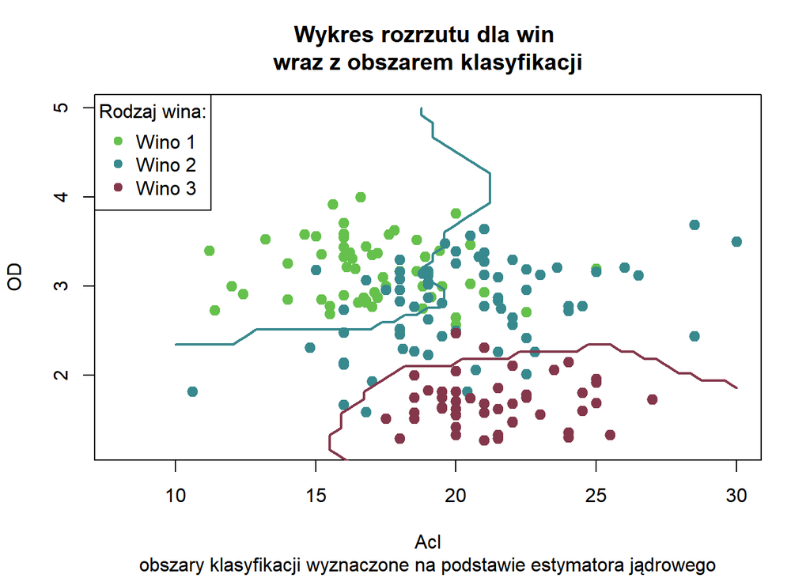

```r
plot(x$Acl[x$Wine == "1"], x$OD[x$Wine == "1"],pch=19,col='#65C14C',cex=1.2,
     xlim = c(8,30),
     ylim = c(1.2,5),
     main = "Wykres rozrzutu dla win \nwraz z obszarem klasyfikacji",
     sub = "obszary klasyfikacji wyznaczone na podstawie estymatora jądrowego",
     xlab = 'Acl',
     ylab = 'OD')
points(x$Acl[x$Wine == "2"], x$OD[x$Wine == "2"],pch=19,col='#38898E',cex=1.2)
points(x$Acl[x$Wine == "3"], x$OD[x$Wine == "3"],pch=19,col='#84374B',cex=1.2)

contour(gest1$x,gest1$y,obszar1,add = T,lwd=2,levels = 0.5,method="simple", col = "#65C14C",
        labels="")
contour(gest2$x,gest2$y,obszar2,add=T,lwd=2,levels = 0.5,method="simple", col = "#38898E",
        labels="")
contour(gest3$x,gest3$y,obszar3,add=T,lwd=2,levels =0.5,method="simple", col = "#84374B",
        labels="")
legend("topleft",legend=c("Wino 1", "Wino 2", "Wino 3"), pch = 19, col = c("#65C14C", "#38898E", "#84374B"), title =  "Rodzaj wina:")
```

Ostatecznie, na podstawie wyznaczonych reguł klasyfikacyjnych można dokonać reklasyfikacji obserwacji ze zbioru danych.

```r
reklas = vector(length = nrow(x))
for(i in 1:nrow(x)){
  g1=kde2d(x$Acl[x$Wine == "1"], x$OD[x$Wine == "1"],
           lims=c(x$Acl[i],x$Acl[i],
                  x$OD[i],x$OD[i]),n=1)

  g2=kde2d(x$Acl[x$Wine == "2"], x$OD[x$Wine == "2"],
           lims=c(x$Acl[i],x$Acl[i],
                  x$OD[i],x$OD[i]),n=1)

  g3=kde2d(x$Acl[x$Wine == "3"], x$OD[x$Wine == "3"],
           lims=c(x$Acl[i],x$Acl[i],
                  x$OD[i],x$OD[i]),n=1)

  if(g1$z>g2$z & g1$z>g3$z){reklas[i]="1"}
  if(g2$z>g1$z & g2$z>g3$z){reklas[i]="2"}
  if(g3$z>g1$z & g3$z>g2$z){reklas[i]="3"}
}
```

Po dokonanej reklasyfikacji można wyznaczyć tabelę klasyfikacji oraz obliczyć procent porpawnej klasyfikacji

```r
table(reklas,x$Wine)
```

```
##
## reklas  1  2  3
##      1 49 16  0
##      2 10 51  2
##      3  0  4 46
```

```r
print(noquote(
  paste("Procent poprawnej klasyfikacji:", round(sum(diag(table(reklas, x$Wine)))/nrow(x)*100,2), "%")))
```

```
## [1] Procent poprawnej klasyfikacji: 82.02 %
```

82% Obserwacji zostało zaklasyfikowanych poprawnie, co wskazuje na wysoką skuteczność wykorzystanego klasyfikatora.

### Zadanie b) i c)

#### Treść zadania:

Dla każdej wartości (klasy) zmiennej Z znaleźć gęstości dwuwymiarowe rozkładu normalnego opisujące rozkład X i Y. Następnie za pomocą otrzymanych gęstości wyznaczyć obszary klasyfikacji (zrobić odpowiedni rysunek) i wyznaczyć procent poprawnej reklasyfikacji. Porównać procent poprawnej reklasyfikacji w podpunktach a) i b).

Aby dopasować rozkład normalny do danych klas należy wyznaczyć poszczególne wartości parametrów dla rozkładu normalnego:

```r
mu1Acl=mean(x$Acl[x$Wine == '1'])
mu1OD=mean(x$OD[x$Wine == '1'])
mu_1 = c(mu1Acl, mu1OD)

mu2Acl=mean(x$Acl[x$Wine == '2'])
mu2OD=mean(x$OD[x$Wine == '2'])
mu_2 = c(mu2Acl, mu2OD)

mu3Acl=mean(x$Acl[x$Wine == '3'])
mu3OD=mean(x$OD[x$Wine == '3'])
mu_3 = c(mu3Acl, mu3OD)

var_1=var(x[x$Wine == '1', 2:3])
var_2=var(x[x$Wine == '2', 2:3])
var_3=var(x[x$Wine == '3', 2:3])
```

Po wyznaczeniu wartości parametrów dla dwuwymiarowych rozkładów normalnych dla każdej z kategorii win można wyznaczyć gęstość rozkładu normalnego dla siatki punktów i przedstawić rezultat na wykresie:

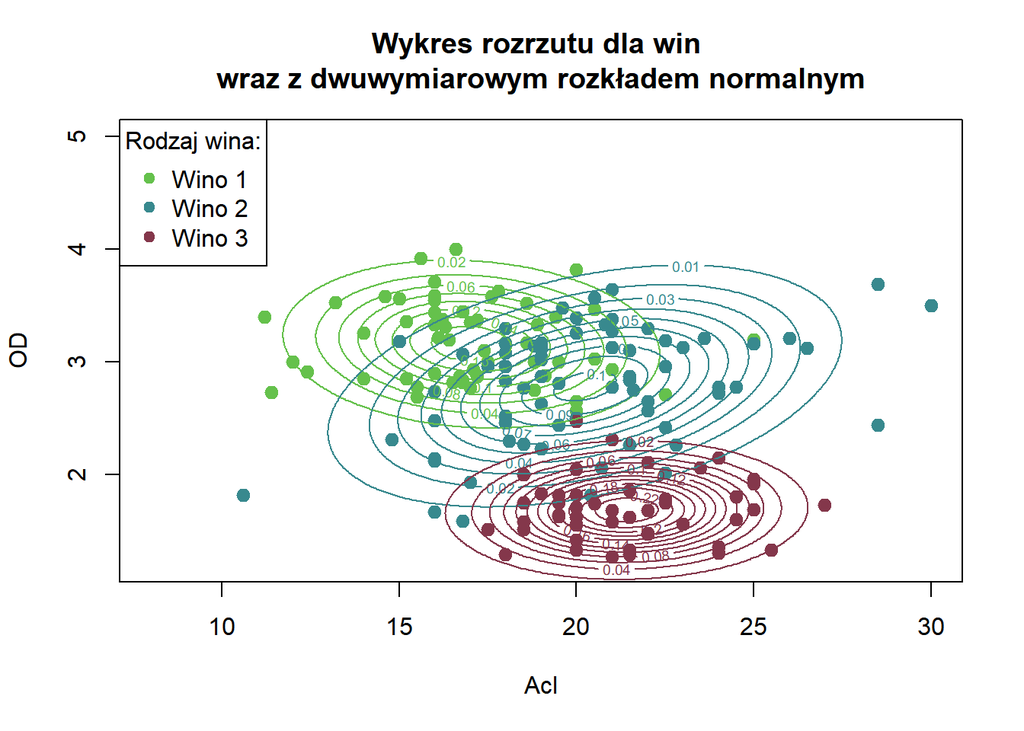

```r
gest1=function(x){dmvnorm(x,mu=mu_1,sigma=var_1)}
gest2=function(x){dmvnorm(x,mu=mu_2,sigma=var_2)}
gest3=function(x){dmvnorm(x,mu=mu_3,sigma=var_3)}

N=300
x1=seq(from=10,to=30,length.out = N)
y=seq(from=1,to=4,length.out = N)
siatka=expand.grid(x=x1,y=y)

wek1=gest1(as.matrix(siatka))
norm1_z=matrix(wek1,nrow=N,ncol=N)

wek2=gest2(as.matrix(siatka))
norm2_z=matrix(wek2,nrow=N,ncol=N)

wek3=gest3(as.matrix(siatka))
norm3_z=matrix(wek3,nrow=N,ncol=N)

plot(x$Acl[x$Wine == "1"], x$OD[x$Wine == "1"],pch=19,col='#65C14C',cex=1.2,
     xlim = c(8,30),
     ylim = c(1.2,5),
     main = "Wykres rozrzutu dla win \nwraz z dwuwymiarowym rozkładem normalnym",
     xlab = 'Acl',
     ylab = 'OD')
points(x$Acl[x$Wine == "2"], x$OD[x$Wine == "2"],pch=19,col='#38898E',cex=1.2)
points(x$Acl[x$Wine == "3"], x$OD[x$Wine == "3"],pch=19,col='#84374B',cex=1.2)
legend('topleft',legend=c("Wino 1", "Wino 2", "Wino 3"), pch = 19, col = c("#65C14C", "#38898E", "#84374B"), title =  "Rodzaj wina:")

contour(x1,y,norm1_z,add=T,col="#65C14C")
contour(x1,y,norm2_z,add=T,col="#38898E")
contour(x1,y,norm3_z,add=T,col="#84374B")
```

Nastepnym krokiem jest znalezienie obszarów klasyfikacji, podobnie jak w zadaniu a) obszary klasyfikacji zostaną wyznaczone na podstawie największej gęstości w danym punkcie. Obszary klasyfikacji zaprezentowano na wykresie poniżej:

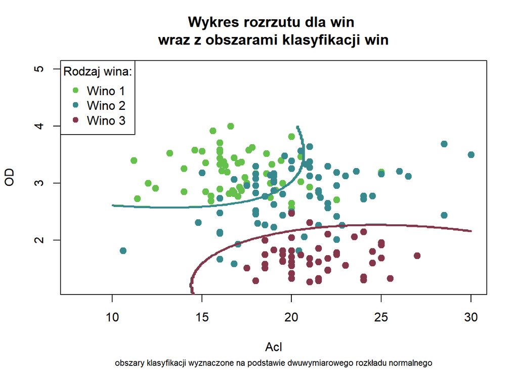

```r
clas1=ifelse(norm1_z>norm2_z & norm1_z>norm3_z,1,0)
clas2=ifelse(norm2_z>norm1_z & norm2_z>norm3_z,1,0)
clas3=ifelse(norm3_z>norm1_z & norm3_z>norm2_z,1,0)

plot(x$Acl[x$Wine == "1"], x$OD[x$Wine == "1"],pch=19,col='#65C14C',cex=1.2,
     xlim = c(8,30),
     ylim = c(1.2,5),
     main = "Wykres rozrzutu dla win \nwraz z obszarami klasyfikacji win",
     sub = "obszary klasyfikacji wyznaczone na podstawie dwuwymiarowego rozkładu normalnego",
     cex.sub = 0.7,
     xlab = 'Acl',
     ylab = 'OD')
points(x$Acl[x$Wine == "2"], x$OD[x$Wine == "2"],pch=19,col='#38898E',cex=1.2)
points(x$Acl[x$Wine == "3"], x$OD[x$Wine == "3"],pch=19,col='#84374B',cex=1.2)
legend('topleft',legend=c("Wino 1", "Wino 2", "Wino 3"), pch = 19, col = c("#65C14C", "#38898E", "#84374B"), title =  "Rodzaj wina:")

contour(x1,y,clas1,add=T,method="simple",labels="",lwd=2, col = '#65C14C')
contour(x1,y,clas2,add=T,method="simple",labels="",lwd=2, col = '#38898E')
contour(x1,y,clas3,add=T,method="simple",labels="",lwd=2, col = '#84374B')
```

Ostatnim etapem jest dokonanie reklasyfikacji zbioru na podstawie wyznaczonych obszarów.

```r
reklas1=vector(length=nrow(x))
for(i in 1:nrow(x)){
  arg=as.numeric(x[i,2:3])
  if(gest1(arg)>gest2(arg) & gest1(arg)>gest3(arg)){reklas1[i]="1"}
  if(gest2(arg)>gest1(arg) & gest2(arg)>gest3(arg)){reklas1[i]="2"}
  if(gest3(arg)>gest2(arg) & gest3(arg)>gest1(arg)){reklas1[i]="3"}
}
```

W celu weryfikacji jakości klasyfikatora można utworzyć macierz pomyłek i na jej podstawić procent poprawnej klasyfikacji.

```r
table(reklas1,x$Wine)
```

```
##
## reklas1  1  2  3
##       1 51 19  0
##       2  8 46  2
##       3  0  6 46
```

```r
print(noquote(
  paste("Procent poprawnej klasyfikacji:", round(sum(diag(table(reklas1, x$Wine)))/nrow(x)*100,2), "%")))
```

```
## [1] Procent poprawnej klasyfikacji: 80.34 %
```

Okazuje się, że klasyfikator opary na rozkładzie normalnym wykazuje nieco gorszą zdolność predykcyjną niż ten oparty na jądrowym estymatorze gęstości. Różnica w odsetku poprawnie zaklasyfikowanych obserwacji jest jednak nieduża i wynosi 2 punkty procentowe.